# Additional Figures

Accompanying ‘Plaque expression levels of HDAC9 in association with plaque vulnerability traits and secondary vascular events in patients undergoing carotid endarterectomy, an analysis in the Athero-EXPRESS Biobank.’

[Sander W. van der Laan, PhD](https://swvanderlaan.github.io) | @swvanderlaan.

2022-03-19

# General Setup

```r
source(paste0(PROJECT_loc, "/scripts/functions.R"))
```

```r
install.packages.auto("readr")
install.packages.auto("optparse")
install.packages.auto("tools")
install.packages.auto("dplyr")
install.packages.auto("tidyr")
install.packages.auto("naniar")

# To get 'data.table' with 'fwrite' to be able to directly write gzipped-files
# Ref: https://stackoverflow.com/questions/42788401/is-possible-to-use-fwrite-from-data-table-with-gzfile
# install.packages("data.table", repos = "https://Rdatatable.gitlab.io/data.table")
library(data.table)

install.packages.auto("tidyverse")
install.packages.auto("knitr")
install.packages.auto("DT")
install.packages.auto("MASS")
# install.packages.auto("Seurat") # latest version

# Install the devtools package from Hadley Wickham
install.packages.auto('devtools')

install.packages.auto("haven")
install.packages.auto("sjlabelled")
install.packages.auto("sjPlot")
install.packages.auto("labelled")
install.packages.auto("tableone")

install.packages.auto("ggpubr")
```

# Background

This notebook contains additional figures of the project “Plaque expression levels of *HDAC9* in association with plaque vulnerability traits and secondary vascular events in patients undergoing carotid endarterectomy: an analysis in the Athero-EXPRESS Biobank.”.

# Loading data

```r
# load(paste0(PROJECT_loc, "/",Today,".",PROJECTNAME,".bulkRNAseq.main_analysis.RData"))
load(paste0(PROJECT_loc, "/20220319.",PROJECTNAME,".bulkRNAseq.main_analysis.RData"))
```

# Fix some variables

We need to get the ‘conventional unit’ versions of cholesterols.

```r
AERNASE.clin.hdac9 <- merge(AERNASE.clin.hdac9,
                            subset(AEDB.CEA, select = c("STUDY_NUMBER",
                                                        "risk614",
                                                        "LDL_finalCU", "HDL_finalCU", "TC_finalCU", "TG_finalCU")),
                            by.x = "STUDY_NUMBER", by.y = "STUDY_NUMBER", sort = TRUE, all.x = TRUE)
```

# Additional figures

## Age and sex

We want to create per-age-group figures median ± interquartile range.

- Box and Whisker plot for HDAC9 plaque levels by sex.
- Box and Whisker plot for HDAC9 plaque levels by (sex and) age group (<55, 55-64, 65-74, 75-84, 85+).

```r
# ?ggpubr::ggboxplot()
compare_means(HDAC9 ~ Gender,  data = AERNASE.clin.hdac9, method = "kruskal.test")
ggpubr::ggboxplot(AERNASE.clin.hdac9,
                  x = c("Gender"),
                  y = "HDAC9",
                  xlab = "gender",
                  ylab = "HDAC9 (normalized expression)",
                  color = "Gender",
                  palette = c("#D5267B", "#1290D9"),
                  add = "jitter") +
  stat_compare_means(aes(group = Gender), label = "p.format", method = "kruskal.test")
ggsave(file = paste0(PLOT_loc, "/",Today,".AERNASE.clin.hdac9.",TRAIT_OF_INTEREST,".plaque.Gender.pdf"), plot = last_plot())
```

```r
library(dplyr)

AERNASE.clin.hdac9 <- AERNASE.clin.hdac9 %>% dplyr::mutate(AgeGroup = factor(case_when(Age < 55 ~ "<55",
                                                     Age >= 55  & Age <= 64 ~ "55-64",
                                                     Age >= 65  & Age <= 74 ~ "65-74",
                                                     Age >= 75  & Age <= 84 ~ "75-84",
                                                     Age >= 85 ~ "85+")))

AERNASE.clin.hdac9 <- AERNASE.clin.hdac9 %>% dplyr::mutate(AgeGroupSex = factor(case_when(Age < 55 & Gender == "male" ~ "<55 males" ,
                                                        Age >= 55  & Age <= 64 & Gender == "male"~ "55-64 males",
                                                        Age >= 65  & Age <= 74 & Gender == "male"~ "65-74 males",
                                                        Age >= 75  & Age <= 84 & Gender == "male"~ "75-84 males",
                                                        Age >= 85 & Gender == "male"~ "85+ males",
                                                        Age < 55 & Gender == "female" ~ "<55 females" ,
                                                        Age >= 55  & Age <= 64 & Gender == "female"~ "55-64 females ",
                                                        Age >= 65  & Age <= 74 & Gender == "female"~ "65-74 females",
                                                        Age >= 75  & Age <= 84 & Gender == "female"~ "75-84 females",
                                                        Age >= 85 & Gender == "female"~ "85+ females")))

table(AERNASE.clin.hdac9$AgeGroup, AERNASE.clin.hdac9$Gender)
table(AERNASE.clin.hdac9$AgeGroupSex)
```

Now we can draw some graphs of plaque HDAC9 levels per sex and age group as median ± interquartile range.

```r
# ?ggpubr::ggboxplot()
compare_means(HDAC9 ~ AgeGroup,  data = AERNASE.clin.hdac9, method = "kruskal.test")
ggpubr::ggboxplot(AERNASE.clin.hdac9,
                  x = c("AgeGroup"),
                  y = "HDAC9",
                  xlab = "Age groups (years)",
                  ylab = "HDAC9 (normalized expression)",
                  color = "AgeGroup",
                  palette = "npg",
                  # add = "median_iqr")
                  add = c("median_iqr", "jitter")) +
  stat_compare_means(aes(group = AgeGroup), label = "p.format", method = "kruskal.test")
ggsave(file = paste0(PLOT_loc, "/",Today,".AERNASE.clin.hdac9.",TRAIT_OF_INTEREST,".plaque.AgeGroup.pdf"), plot = last_plot())

compare_means(HDAC9 ~ AgeGroup, group.by = "Gender", data = AERNASE.clin.hdac9, method = "kruskal.test")
ggpubr::ggboxplot(AERNASE.clin.hdac9,
                  x = c("AgeGroup"),
                  y = "HDAC9",
                  xlab = "Age groups (years) per gender",
                  ylab = "HDAC9 (normalized expression",
                  color = "Gender",
                  palette = c("#D5267B", "#1290D9"),
                  # add = "median_iqr")
                  add = c("median_iqr", "jitter")) +
  stat_compare_means(aes(group = Gender), label = "p.format", method = "kruskal.test")
ggsave(file = paste0(PLOT_loc, "/",Today,".AERNASE.clin.hdac9.",TRAIT_OF_INTEREST,".plaque.AgeGroup_perGender.pdf"), plot = last_plot())
```

## Hypertension & blood pressure

We want to create figures of HDAC9 levels stratified by hypertension/blood pressure, and use of anti-hypertensive drugs.

- Box and Whisker plot for HDAC9 plaque levels by hypertension group (no, yes)
- Box and Whisker plot for HDAC9 plaque levels by systolic blood pressure group (<120, 120-139, 140-159,160+)

```r
library(dplyr)

AERNASE.clin.hdac9 <- AERNASE.clin.hdac9 %>% mutate(SBPGroup = factor(case_when(systolic < 120 ~ "<120",
                                                     systolic >= 120  & systolic <= 139 ~ "120-139",
                                                     systolic >= 140  & systolic <= 159 ~ "140-159",
                                                     systolic >= 160 ~ "160+")))

table(AERNASE.clin.hdac9$SBPGroup, AERNASE.clin.hdac9$Gender)
```

Now we can draw some graphs of plaque HDAC9 levels per sex and hypertension/blood pressure group as median ± interquartile range.

```r
compare_means(HDAC9 ~ SBPGroup, data = AERNASE.clin.hdac9 %>% filter(!is.na(SBPGroup)), method = "kruskal.test")
ggpubr::ggboxplot(AERNASE.clin.hdac9 %>% filter(!is.na(SBPGroup)),
                  x = c("SBPGroup"),
                  y = "HDAC9",
                  xlab = "Systolic blood pressure (mmHg)",
                  ylab = "HDAC9 (normalized expression)",
                  color = "SBPGroup",
                  palette = "npg",
                  add = "jitter") +
  stat_compare_means(aes(group = SBPGroup), label = "p.format", method = "kruskal.test")
ggsave(file = paste0(PLOT_loc, "/",Today,".AERNASE.clin.hdac9.",TRAIT_OF_INTEREST,".plaque.SBPGroup.pdf"), plot = last_plot())

compare_means(HDAC9 ~ Hypertension.selfreport, data = AERNASE.clin.hdac9 %>% filter(!is.na(Hypertension.selfreport)), method = "kruskal.test")
ggpubr::ggboxplot(AERNASE.clin.hdac9 %>% filter(!is.na(Hypertension.selfreport)),
                  x = c("Hypertension.selfreport"),
                  y = "HDAC9",
                  xlab = "Self-reported hypertension",
                  ylab = "HDAC9 (normalized expression)",
                  color = "Hypertension.selfreport",
                  palette = "npg",
                  add = "jitter") +
  stat_compare_means(aes(group = Hypertension.selfreport), label = "p.format", method = "kruskal.test")
ggsave(file = paste0(PLOT_loc, "/",Today,".AERNASE.clin.hdac9.",TRAIT_OF_INTEREST,".plaque.Hypertension.pdf"), plot = last_plot())

compare_means(HDAC9 ~ Hypertension.drugs, data = AERNASE.clin.hdac9 %>% filter(!is.na(Hypertension.drugs)), method = "kruskal.test")
ggpubr::ggboxplot(AERNASE.clin.hdac9 %>% filter(!is.na(Hypertension.drugs)),
                  x = c("Hypertension.drugs"),
                  y = "HDAC9",
                  xlab = "Hypertension medication use",
                  ylab = "HDAC9 (normalized expression)",
                  color = "Hypertension.drugs",
                  palette = "npg",
                  add = "jitter") +
  stat_compare_means(aes(group = Hypertension.drugs), label = "p.format", method = "kruskal.test")
ggsave(file = paste0(PLOT_loc, "/",Today,".AERNASE.clin.hdac9.",TRAIT_OF_INTEREST,".plaque.HypertensionDrugs.pdf"), plot = last_plot())



compare_means(HDAC9 ~ SBPGroup, group.by = "Gender", data = AERNASE.clin.hdac9 %>% filter(!is.na(SBPGroup)), method = "kruskal.test")
ggpubr::ggboxplot(AERNASE.clin.hdac9 %>% filter(!is.na(SBPGroup)),
                  x = c("SBPGroup"),
                  y = "HDAC9",
                  xlab = "Systolic blood pressure (mmHg) per gender",
                  ylab = "HDAC9 (normalized expression)",
                  color = "Gender",
                  palette = c("#D5267B", "#1290D9"),
                  add = "jitter") +
  stat_compare_means(aes(group = Gender), label = "p.format", method = "kruskal.test")
ggsave(file = paste0(PLOT_loc, "/",Today,".AERNASE.clin.hdac9.",TRAIT_OF_INTEREST,".plaque.SBPGroup_byGender.pdf"), plot = last_plot())

compare_means(HDAC9 ~ Hypertension.selfreport, group.by = "Gender", data = AERNASE.clin.hdac9 %>% filter(!is.na(Hypertension.selfreport)), method = "kruskal.test")
ggpubr::ggboxplot(AERNASE.clin.hdac9 %>% filter(!is.na(Hypertension.selfreport)),
                  x = c("Hypertension.selfreport"),
                  y = "HDAC9",
                  xlab = "Self-reported hypertension per gender",
                  ylab = "HDAC9 (normalized expression)",
                  color = "Gender",
                  palette = c("#D5267B", "#1290D9"),
                  add = "jitter") +
  stat_compare_means(aes(group = Gender), label = "p.format", method = "kruskal.test")
ggsave(file = paste0(PLOT_loc, "/",Today,".AERNASE.clin.hdac9.",TRAIT_OF_INTEREST,".plaque.Hypertension_byGender.pdf"), plot = last_plot())

compare_means(HDAC9 ~ Hypertension.drugs, group.by = "Gender", data = AERNASE.clin.hdac9 %>% filter(!is.na(Hypertension.drugs)), method = "kruskal.test")
ggpubr::ggboxplot(AERNASE.clin.hdac9 %>% filter(!is.na(Hypertension.drugs)),
                  x = c("Hypertension.drugs"),
                  y = "HDAC9",
                  xlab = "Hypertension medication use per gender",
                  ylab = "HDAC9 (normalized expression)",
                  color = "Gender",
                  palette = c("#D5267B", "#1290D9"),
                  add = "jitter") +
  stat_compare_means(aes(group = Gender), label = "p.format", method = "kruskal.test")
ggsave(file = paste0(PLOT_loc, "/",Today,".AERNASE.clin.hdac9.",TRAIT_OF_INTEREST,".plaque.Hypertension.drugs_byGender.pdf"), plot = last_plot())



compare_means(HDAC9 ~ SBPGroup, group.by = "Hypertension.drugs", data = AERNASE.clin.hdac9 %>% filter(!is.na(SBPGroup) & !is.na(Hypertension.drugs)), method = "kruskal.test")
ggpubr::ggboxplot(AERNASE.clin.hdac9 %>% filter(!is.na(SBPGroup) & !is.na(Hypertension.drugs)),
                  x = c("SBPGroup"),
                  y = "HDAC9",
                  xlab = "Systolic blood pressure (mmHg) by medication use",
                  ylab = "HDAC9 (normalized expression)",
                  color = "Hypertension.drugs",
                  palette = c("#49A01D", "#1290D9"),
                  add = "jitter") +
  stat_compare_means(aes(group = Hypertension.drugs), label = "p.format", method = "kruskal.test")
ggsave(file = paste0(PLOT_loc, "/",Today,".AERNASE.clin.hdac9.",TRAIT_OF_INTEREST,".plaque.SBPGroup_byHypertensionDrugs.pdf"), plot = last_plot())

compare_means(HDAC9 ~ Hypertension.selfreport, group.by = "Hypertension.drugs", data = AERNASE.clin.hdac9 %>% filter(!is.na(Hypertension.selfreport) & !is.na(Hypertension.drugs)), method = "kruskal.test")
ggpubr::ggboxplot(AERNASE.clin.hdac9 %>% filter(!is.na(Hypertension.selfreport) & !is.na(Hypertension.drugs)),
                  x = c("Hypertension.selfreport"),
                  y = "HDAC9",
                  xlab = "Self-reported hypertension per medication use",
                  ylab = "HDAC9 (normalized expression)",
                  color = "Hypertension.drugs",
                  palette = c("#49A01D", "#1290D9"),
                  add = "jitter") +
  stat_compare_means(aes(group = Hypertension.drugs), label = "p.format", method = "kruskal.test")
ggsave(file = paste0(PLOT_loc, "/",Today,".AERNASE.clin.hdac9.",TRAIT_OF_INTEREST,".plaque.Hypertension.selfreport_byHypertensionDrugs.pdf"), plot = last_plot())
```

## Hypercholesterolemia & LDL levels

We want to create figures of HDAC9 levels stratified by hypercholesterolemia/LDL-levels, and use of lipid-lowering drugs.

```r
library(dplyr)

AERNASE.clin.hdac9 <- AERNASE.clin.hdac9 %>% mutate(LDLGroup = factor(case_when(LDL_finalCU < 100 ~ "<100",
                                                     LDL_finalCU >= 100  & LDL_finalCU <= 129 ~ "100-129",
                                                     LDL_finalCU >= 130  & LDL_finalCU <= 159 ~ "130-159",
                                                     LDL_finalCU >= 160  & LDL_finalCU <= 189 ~ "160-189",
                                                     LDL_finalCU >= 190 ~ "190+")))


table(AERNASE.clin.hdac9$LDLGroup, AERNASE.clin.hdac9$Gender)
```

```r
require(sjlabelled)

AERNASE.clin.hdac9$risk614 <- to_factor(AERNASE.clin.hdac9$risk614)

# Fix plaquephenotypes
attach(AERNASE.clin.hdac9)
AERNASE.clin.hdac9[,"Hypercholesterolemia"] <- NA
AERNASE.clin.hdac9$Hypercholesterolemia[risk614 == "missing value"] <- NA
AERNASE.clin.hdac9$Hypercholesterolemia[risk614 == -999] <- NA
AERNASE.clin.hdac9$Hypercholesterolemia[risk614 == 0] <- "no"
AERNASE.clin.hdac9$Hypercholesterolemia[risk614 == 1] <- "yes"
detach(AERNASE.clin.hdac9)

table(AERNASE.clin.hdac9$risk614, AERNASE.clin.hdac9$Hypercholesterolemia)

# AEDB.temp <- subset(AEDB,  select = c("STUDY_NUMBER", "UPID", "Age", "Gender", "Hospital", "Artery_summary", "risk614", "Hypercholesterolemia"))
# require(labelled)
# AEDB.temp$Gender <- to_factor(AEDB.temp$Gender)
# AEDB.temp$Hospital <- to_factor(AEDB.temp$Hospital)
# AEDB.temp$Artery_summary <- to_factor(AEDB.temp$Artery_summary)
#
# DT::datatable(AEDB.temp[1:10,], caption = "Excerpt of the whole AEDB.", rownames = FALSE)
#
# rm(AEDB.temp)
```

Now we can draw some graphs of plaque HDAC9 levels per sex and hypercholesterolemia/LDL-levels group, as well as stratified by lipid-lowering drugs users as median ± interquartile range.

```r
compare_means(HDAC9 ~ LDLGroup, data = AERNASE.clin.hdac9 %>% filter(!is.na(LDLGroup)), method = "kruskal.test")
ggpubr::ggboxplot(AERNASE.clin.hdac9 %>% filter(!is.na(LDLGroup)),
                  x = c("LDLGroup"),
                  y = "HDAC9",
                  xlab = "LDL (mg/dL) per gender",
                  ylab = "HDAC9 (normalized expression))",
                  color = "LDLGroup",
                  palette = "npg",
                  add = "jitter") +
  stat_compare_means(label = "p.format", method = "kruskal.test")
ggsave(file = paste0(PLOT_loc, "/",Today,".AERNASE.clin.hdac9.",TRAIT_OF_INTEREST,".plaque.LDLGroups.pdf"), plot = last_plot())

compare_means(HDAC9 ~ LDLGroup, group.by = "Gender", data = AERNASE.clin.hdac9 %>% filter(!is.na(LDLGroup)), method = "kruskal.test")
ggpubr::ggboxplot(AERNASE.clin.hdac9 %>% filter(!is.na(LDLGroup)),
                  x = c("LDLGroup"),
                  y = "HDAC9",
                  xlab = "LDL (mg/dL) per gender",
                  ylab = "HDAC9 (normalized expression))",
                  color = "Gender",
                  palette = c("#D5267B", "#1290D9"),
                  add = "jitter") +
  stat_compare_means(aes(group = Gender), label = "p.format", method = "kruskal.test")
ggsave(file = paste0(PLOT_loc, "/",Today,".AERNASE.clin.hdac9.",TRAIT_OF_INTEREST,".plaque.LDLGroups_byGender.pdf"), plot = last_plot())



compare_means(HDAC9 ~ Hypercholesterolemia, data = AERNASE.clin.hdac9 %>% filter(!is.na(Hypercholesterolemia)), method = "kruskal.test")
ggpubr::ggboxplot(AERNASE.clin.hdac9 %>% filter(!is.na(Hypercholesterolemia)),
                  x = c("Hypercholesterolemia"),
                  y = "HDAC9",
                  xlab = "Diagnosed hypercholesterolemia",
                  ylab = "HDAC9 (normalized expression))",
                  color = "Hypercholesterolemia",
                  palette = "npg",
                  add = "jitter") +
  stat_compare_means(label = "p.format", method = "kruskal.test")
ggsave(file = paste0(PLOT_loc, "/",Today,".AERNASE.clin.hdac9.",TRAIT_OF_INTEREST,".plaque.Hypercholesterolemia.pdf"), plot = last_plot())

compare_means(HDAC9 ~ Hypercholesterolemia, group.by = "Gender", data = AERNASE.clin.hdac9 %>% filter(!is.na(Hypercholesterolemia)), method = "kruskal.test")
ggpubr::ggboxplot(AERNASE.clin.hdac9 %>% filter(!is.na(Hypercholesterolemia)),
                  x = c("Hypercholesterolemia"),
                  y = "HDAC9",
                  xlab = "Diagnosed hypercholesterolemia per gender",
                  ylab = "HDAC9 (normalized expression))",
                  color = "Gender",
                  palette = c("#D5267B", "#1290D9"),
                  add = "jitter") +
  stat_compare_means(aes(group = Gender), label = "p.format", method = "kruskal.test")
ggsave(file = paste0(PLOT_loc, "/",Today,".AERNASE.clin.hdac9.",TRAIT_OF_INTEREST,".plaque.Hypercholesterolemia_byGender.pdf"), plot = last_plot())


compare_means(HDAC9 ~ Med.Statin.LLD, data = AERNASE.clin.hdac9 %>% filter(!is.na(Med.Statin.LLD)), method = "kruskal.test")
ggpubr::ggboxplot(AERNASE.clin.hdac9 %>% filter(!is.na(Med.Statin.LLD)),
                  x = c("Med.Statin.LLD"),
                  y = "HDAC9",
                  xlab = "Lipid-lowering drug use",
                  ylab = "HDAC9 (normalized expression))",
                  color = "Med.Statin.LLD",
                  palette = "npg",
                  add = "jitter") +
  stat_compare_means(label = "p.format", method = "kruskal.test")
ggsave(file = paste0(PLOT_loc, "/",Today,".AERNASE.clin.hdac9.",TRAIT_OF_INTEREST,".plaque.Med.Statin.LLD.pdf"), plot = last_plot())

compare_means(HDAC9 ~ Med.Statin.LLD, group.by = "Gender", data = AERNASE.clin.hdac9 %>% filter(!is.na(Med.Statin.LLD)), method = "kruskal.test")
ggpubr::ggboxplot(AERNASE.clin.hdac9 %>% filter(!is.na(Med.Statin.LLD)),
                  x = c("Med.Statin.LLD"),
                  y = "HDAC9",
                  xlab = "Lipid-lowering drug use per gender",
                  ylab = "HDAC9 (normalized expression))",
                  color = "Gender",
                  palette = c("#D5267B", "#1290D9"),
                  add = "jitter") +
  stat_compare_means(aes(group = Gender), label = "p.format", method = "kruskal.test")
ggsave(file = paste0(PLOT_loc, "/",Today,".AERNASE.clin.hdac9.",TRAIT_OF_INTEREST,".plaque.Med.Statin.LLD_byGender.pdf"), plot = last_plot())




compare_means(HDAC9 ~ LDLGroup, group.by = "Med.Statin.LLD", data = AERNASE.clin.hdac9 %>% filter(!is.na(LDLGroup) & !is.na(Med.Statin.LLD)), method = "kruskal.test")
ggpubr::ggboxplot(AERNASE.clin.hdac9 %>% filter(!is.na(LDLGroup) & !is.na(Med.Statin.LLD)),
                  x = c("LDLGroup"),
                  y = "HDAC9",
                  xlab = "LDL (mg/dL) per LLD use",
                  ylab = "HDAC9 (normalized expression))",
                  color = "Med.Statin.LLD",
                  palette = c("#49A01D", "#1290D9"),
                  add = "jitter") +
  stat_compare_means(aes(group = Med.Statin.LLD), label = "p.format", method = "kruskal.test")
ggsave(file = paste0(PLOT_loc, "/",Today,".AERNASE.clin.hdac9.",TRAIT_OF_INTEREST,".plaque.LDLGroups_byMed.Statin.LLD.pdf"), plot = last_plot())

compare_means(HDAC9 ~ Hypercholesterolemia, group.by = "Med.Statin.LLD", data = AERNASE.clin.hdac9 %>% filter(!is.na(Hypercholesterolemia) & !is.na(Med.Statin.LLD)), method = "kruskal.test")
ggpubr::ggboxplot(AERNASE.clin.hdac9 %>% filter(!is.na(Hypercholesterolemia) & !is.na(Med.Statin.LLD)),
                  x = c("Hypercholesterolemia"),
                  y = "HDAC9",
                  xlab = "Diagnosed hypercholesterolemia per LLD use",
                  ylab = "HDAC9 (normalized expression))",
                  color = "Med.Statin.LLD",
                  palette = c("#49A01D", "#1290D9"),
                  add = "jitter") +
  stat_compare_means(aes(group = Med.Statin.LLD), label = "p.format", method = "kruskal.test")
ggsave(file = paste0(PLOT_loc, "/",Today,".AERNASE.clin.hdac9.",TRAIT_OF_INTEREST,".plaque.LDLGroups_byMed.Statin.LLD.pdf"), plot = last_plot())
```

## Kidney function (eGFR)

We want to create figures of HDAC9 levels stratified by kidney function.

- Box and Whisker plot for HDAC9 plaque levels by chronic kidney disease (CKD) group (1, 2, 3, 4, 5)
- Box and Whisker plot for HDAC9 plaque levels by eGFR (MDRD-based) group (90+, 60-89, 30-59, <30)

```r
library(dplyr)

AERNASE.clin.hdac9 <- AERNASE.clin.hdac9 %>% mutate(eGFRGroup = factor(case_when(GFR_MDRD < 15 ~ "<15",
                                                             GFR_MDRD >= 15  & GFR_MDRD <= 29 ~ "15-29",
                                                             GFR_MDRD >= 30  & GFR_MDRD <= 59 ~ "30-59",
                                                             GFR_MDRD >= 60  & GFR_MDRD <= 89 ~ "60-89",
                                                             GFR_MDRD >= 90 ~ "90+")))

table(AERNASE.clin.hdac9$eGFRGroup, AERNASE.clin.hdac9$Gender)

table(AERNASE.clin.hdac9$eGFRGroup, AERNASE.clin.hdac9$KDOQI)
```

Now we can draw some graphs of plaque HDAC9 levels per sex and kidney function group as median ± interquartile range.

```r
# Global test

compare_means(HDAC9 ~ eGFRGroup, data = AERNASE.clin.hdac9 %>% filter(!is.na(eGFRGroup)), method = "kruskal.test")
ggpubr::ggboxplot(AERNASE.clin.hdac9 %>% filter(!is.na(eGFRGroup)),
                  x = c("eGFRGroup"),
                  y = "HDAC9",
                  xlab = "eGFR (mL/min per 1.73 m2)",
                  ylab = "HDAC9 (normalized expression)",
                  color = "eGFRGroup",
                  palette = "npg",
                  add = "jitter") +
  stat_compare_means(method = "kruskal.test")
ggsave(file = paste0(PLOT_loc, "/",Today,".AERNASE.clin.hdac9.",TRAIT_OF_INTEREST,".plaque.EGFR.pdf"), plot = last_plot())

compare_means(HDAC9 ~ eGFRGroup, group.by = "Gender",  data = AERNASE.clin.hdac9 %>% filter(!is.na(eGFRGroup)), method = "kruskal.test")
ggpubr::ggboxplot(AERNASE.clin.hdac9 %>% filter(!is.na(eGFRGroup)),
                  x = c("eGFRGroup"),
                  y = "HDAC9",
                  xlab = "eGFR (mL/min per 1.73 m2) per gender",
                  ylab = "HDAC9 (normalized expression)",
                  color = "Gender",
                  palette = c("#D5267B", "#1290D9"),
                  add = "jitter") +
  stat_compare_means(aes(group = Gender), label = "p.format", method = "kruskal.test")
ggsave(file = paste0(PLOT_loc, "/",Today,".AERNASE.clin.hdac9.",TRAIT_OF_INTEREST,".plaque.EGFR_byGender.pdf"), plot = last_plot())

compare_means(HDAC9 ~ KDOQI, data = AERNASE.clin.hdac9 %>% filter(!is.na(KDOQI)), method = "kruskal.test")
p1 <- ggpubr::ggboxplot(AERNASE.clin.hdac9 %>% filter(!is.na(KDOQI)),
                  x = c("KDOQI"),
                  y = "HDAC9",
                  xlab = "Kidney function (KDOQI)",
                  ylab = "HDAC9 (normalized expression)",
                  color = "KDOQI",
                  palette = "npg",
                  add = "jitter") +
  stat_compare_means(aes(group = KDOQI), label = "p.format", method = "kruskal.test")
ggpar(p1 + rotate_x_text(45), legend = "right")
rm(p1)
ggsave(file = paste0(PLOT_loc, "/",Today,".AERNASE.clin.hdac9.",TRAIT_OF_INTEREST,".plaque.KDOQI.pdf"), plot = last_plot())

compare_means(HDAC9 ~ KDOQI, group.by = "Gender",   data = AERNASE.clin.hdac9 %>% filter(!is.na(KDOQI)), method = "kruskal.test")
p1 <- ggpubr::ggboxplot(AERNASE.clin.hdac9 %>% filter(!is.na(KDOQI)),
                  x = c("KDOQI"),
                  y = "HDAC9",
                  xlab = "Kidney function (KDOQI) per gender",
                  ylab = "HDAC9 (normalized expression)",
                  color = "Gender",
                  palette = c("#D5267B", "#1290D9"),
                  add = "jitter") +
  stat_compare_means(aes(group = Gender), label = "p.format", method = "kruskal.test")
ggpar(p1 + rotate_x_text(45), legend = "right")
rm(p1)
ggsave(file = paste0(PLOT_loc, "/",Today,".AERNASE.clin.hdac9.",TRAIT_OF_INTEREST,".plaque.KDOQI_byGender.pdf"), plot = last_plot())

compare_means(HDAC9 ~ eGFRGroup,  data = AERNASE.clin.hdac9 %>% filter(!is.na(eGFRGroup) & !is.na(KDOQI)), method = "kruskal.test")
p1 <- ggpubr::ggboxplot(AERNASE.clin.hdac9 %>% filter(!is.na(eGFRGroup) & !is.na(KDOQI)),
                  x = c("eGFRGroup"),
                  y = "HDAC9",
                  xlab = "eGFR (mL/min per 1.73 m2) by KDOQI group",
                  ylab = "HDAC9 (normalized expression)",
                  color = "KDOQI",
                  palette = "npg",
                  add = "jitter") +
  stat_compare_means(method = "kruskal.test")
ggpar(p1, legend = "right")
rm(p1)
ggsave(file = paste0(PLOT_loc, "/",Today,".AERNASE.clin.hdac9.",TRAIT_OF_INTEREST,".plaque.EGFR_KDOQI.pdf"), plot = last_plot())
```

## BMI

We want to create figures of HDAC9 levels stratified by BMI.

- Box and Whisker plot for HDAC9 plaque levels by BMI WHO group (underweight, normal, overweight, obese)
- Box and Whisker plot for HDAC9 plaque levels by BMI group (<18.5, 18.5-24.9, 25, 29.9, 30-24.9, 35+)

```r
library(dplyr)

AERNASE.clin.hdac9 <- AERNASE.clin.hdac9 %>% mutate(BMIGroup = factor(case_when(BMI < 18.5 ~ "<18.5",
                                                     BMI >= 18.5  & BMI < 25 ~ "18.5-24",
                                                     BMI >= 25  & BMI < 30 ~ "25-29",
                                                     BMI >= 30  & BMI < 35 ~ "30-35",
                                                     BMI >= 35 ~ "35+")))

# require(labelled)
# AERNASE.clin.hdac9$BMI_US <- as_factor(AERNASE.clin.hdac9$BMI_US)
# AERNASE.clin.hdac9$BMI_WHO <- as_factor(AERNASE.clin.hdac9$BMI_WHO)
# table(AERNASE.clin.hdac9$BMI_WHO, AERNASE.clin.hdac9$BMI_US)

table(AERNASE.clin.hdac9$BMIGroup, AERNASE.clin.hdac9$Gender)
table(AERNASE.clin.hdac9$BMIGroup, AERNASE.clin.hdac9$BMI_WHO)
```

```r
# Global test
compare_means(HDAC9 ~ BMIGroup,  data = AERNASE.clin.hdac9 %>% filter(!is.na(BMIGroup)), method = "kruskal.test")
ggpubr::ggboxplot(AERNASE.clin.hdac9 %>% filter(!is.na(BMIGroup)),
                  x = c("BMIGroup"),
                  y = "HDAC9",
                  xlab = "BMI groups (kg/m2)",
                  ylab = "HDAC9 (normalized expression)",
                  # color = "Gender",
                  # palette = c("#D5267B", "#1290D9"),
                  color = "BMIGroup",
                  palette = "npg",
                  add = "jitter") +
  stat_compare_means(label = "p.format", method = "kruskal.test")
ggsave(file = paste0(PLOT_loc, "/",Today,".AERNASE.clin.hdac9.",TRAIT_OF_INTEREST,".plaque.BMI.pdf"), plot = last_plot())

compare_means(HDAC9 ~ BMIGroup, group.by = "Gender", data = AERNASE.clin.hdac9 %>% filter(!is.na(BMIGroup)), method = "kruskal.test")
ggpubr::ggboxplot(AERNASE.clin.hdac9 %>% filter(!is.na(BMIGroup)),
                  x = c("BMIGroup"),
                  y = "HDAC9",
                  xlab = "BMI groups (kg/m2) per gender",
                  ylab = "HDAC9 (normalized expression)",
                  color = "Gender",
                  palette = c("#D5267B", "#1290D9"),
                  add = "jitter") +
  stat_compare_means(aes(group = Gender), label = "p.format", method = "kruskal.test")
ggsave(file = paste0(PLOT_loc, "/",Today,".AERNASE.clin.hdac9.",TRAIT_OF_INTEREST,".plaque.BMI_byGender.pdf"), plot = last_plot())

compare_means(HDAC9 ~ BMIGroup,  data = AERNASE.clin.hdac9 %>% filter(!is.na(BMIGroup) & !is.na(BMI_WHO)), method = "kruskal.test")
p1 <- ggpubr::ggboxplot(AERNASE.clin.hdac9 %>% filter(!is.na(BMIGroup) & !is.na(BMI_WHO)),
                  x = c("BMIGroup"),
                  y = "HDAC9",
                  xlab = "BMI groups (kg/m2) per WHO categories",
                  ylab = "HDAC9 (normalized expression)",
                  color = "BMI_WHO",
                  palette = "npg",
                  add = "jitter") +
  stat_compare_means(method = "kruskal.test")
ggpar(p1, legend = "right")
rm(p1)
ggsave(file = paste0(PLOT_loc, "/",Today,".AERNASE.clin.hdac9.",TRAIT_OF_INTEREST,".plaque.BMI_byWHO.pdf"), plot = last_plot())
```

## Diabetes

We want to create figures of HDAC9 levels stratified by type 2 diabetes.

- Box and Whisker plot for HDAC9 plaque levels by type 2 diabetes group (no, yes)

```r
# Global test
compare_means(HDAC9 ~ DiabetesStatus,  data = AERNASE.clin.hdac9 %>% filter(!is.na(DiabetesStatus)), method = "kruskal.test")
ggpubr::ggboxplot(AERNASE.clin.hdac9 %>% filter(!is.na(DiabetesStatus)),
                  x = c("DiabetesStatus"),
                  y = "HDAC9",
                  xlab = "Diabetes status",
                  ylab = "HDAC9 (normalized expression)",
                  # color = "Gender",
                  # palette = c("#D5267B", "#1290D9"),
                  color = "DiabetesStatus",
                  palette = "npg",
                  add = c("median_iqr", "jitter")) +
  stat_compare_means(label = "p.format", method = "kruskal.test")
ggsave(file = paste0(PLOT_loc, "/",Today,".AERNASE.clin.hdac9.",TRAIT_OF_INTEREST,".plaque.Diabetes.pdf"), plot = last_plot())

compare_means(HDAC9 ~ DiabetesStatus, group.by = "Gender", data = AERNASE.clin.hdac9 %>% filter(!is.na(DiabetesStatus)), method = "kruskal.test")
ggpubr::ggboxplot(AERNASE.clin.hdac9 %>% filter(!is.na(DiabetesStatus)),
                  x = c("DiabetesStatus"),
                  y = "HDAC9",
                  xlab = "Diabetes status per gender",
                  ylab = "HDAC9 (normalized expression)",
                  color = "Gender",
                  palette = c("#D5267B", "#1290D9"),
                  add = c("median_iqr", "jitter")) +
  stat_compare_means(aes(group = Gender), label = "p.format", method = "kruskal.test")
ggsave(file = paste0(PLOT_loc, "/",Today,".AERNASE.clin.hdac9.",TRAIT_OF_INTEREST,".plaque.Diabetes_byGender.pdf"), plot = last_plot())
```

## Smoking

We want to create figures of HDAC9 levels stratified by smoking.

- Box and Whisker plot for HDAC9 plaque levels by smoking group (never, ex, current)

```r
# Global test
compare_means(HDAC9 ~ SmokerStatus,  data = AERNASE.clin.hdac9 %>% filter(!is.na(SmokerStatus)), method = "kruskal.test")
ggpubr::ggboxplot(AERNASE.clin.hdac9 %>% filter(!is.na(SmokerStatus)),
                  x = c("SmokerStatus"),
                  y = "HDAC9",
                  xlab = "Smoker status",
                  ylab = "HDAC9 (normalized expression)",
                  # color = "Gender",
                  # palette = c("#D5267B", "#1290D9"),
                  color = "SmokerStatus",
                  palette = "npg",
                  add = c("median_iqr", "jitter")) +
  stat_compare_means(label = "p.format", method = "kruskal.test")
ggsave(file = paste0(PLOT_loc, "/",Today,".AERNASE.clin.hdac9.",TRAIT_OF_INTEREST,".plaque.Smoking.pdf"), plot = last_plot())

compare_means(HDAC9 ~ SmokerStatus, group.by ="Gender", data = AERNASE.clin.hdac9 %>% filter(!is.na(SmokerStatus)), method = "kruskal.test")
ggpubr::ggboxplot(AERNASE.clin.hdac9 %>% filter(!is.na(SmokerStatus)),
                  x = c("SmokerStatus"),
                  y = "HDAC9",
                  xlab = "Smoker status per gender",
                  ylab = "HDAC9 (normalized expression)",
                  color = "Gender",
                  palette = c("#D5267B", "#1290D9"),
                  add = c("median_iqr", "jitter")) +
  stat_compare_means(aes(group = Gender), label = "p.format", method = "kruskal.test")
ggsave(file = paste0(PLOT_loc, "/",Today,".AERNASE.clin.hdac9.",TRAIT_OF_INTEREST,".plaque.Smoking_byGender.pdf"), plot = last_plot())
```

## Stenosis

We want to create figures of HDAC9 levels stratified by stenosis grade.

- Box and Whisker plot for HDAC9 plaque levels by stenosis grade group (<70, 70-89, 90+)

```r
library(dplyr)

AERNASE.clin.hdac9 <- AERNASE.clin.hdac9 %>% mutate(StenoticGroup = factor(case_when(stenose == "0-49%" ~ "<70",
                                                     stenose == "0-49%" ~ "<70",
                                                     stenose == "50-70%" ~ "<70",
                                                     stenose == "70-90%" ~ "70-89",
                                                     stenose == "50-99%" ~ "90+",
                                                     stenose == "70-99%" ~ "90+",
                                                     stenose == "100% (Occlusion)" ~ "90+",
                                                     stenose == "90-99%" ~ "90+")))

table(AERNASE.clin.hdac9$StenoticGroup, AERNASE.clin.hdac9$Gender)
table(AERNASE.clin.hdac9$stenose, AERNASE.clin.hdac9$StenoticGroup)
```

```r
# Global test
compare_means(HDAC9 ~ StenoticGroup,  data = AERNASE.clin.hdac9 %>% filter(!is.na(StenoticGroup)), method = "kruskal.test")
ggpubr::ggboxplot(AERNASE.clin.hdac9 %>% filter(!is.na(StenoticGroup)),
                  x = c("StenoticGroup"),
                  y = "HDAC9",
                  xlab = "Stenotic grade",
                  ylab = "HDAC9 (normalized expression)",
                  # color = "Gender",
                  # palette = c("#D5267B", "#1290D9"),
                  color = "StenoticGroup",
                  palette = "npg",
                  add = "jitter") +
  stat_compare_means(label = "p.format", method = "kruskal.test")
ggsave(file = paste0(PLOT_loc, "/",Today,".AERNASE.clin.hdac9.",TRAIT_OF_INTEREST,".plaque.Stenosis.pdf"), plot = last_plot())

compare_means(HDAC9 ~ StenoticGroup, group.by = "Gender", data = AERNASE.clin.hdac9 %>% filter(!is.na(StenoticGroup)), method = "kruskal.test")
ggpubr::ggboxplot(AERNASE.clin.hdac9 %>% filter(!is.na(StenoticGroup)),
                  x = c("StenoticGroup"),
                  y = "HDAC9",
                  xlab = "Stenotic grade per gender",
                  ylab = "HDAC9 (normalized expression)",
                  color = "Gender",
                  palette = c("#D5267B", "#1290D9"),
                  add = "jitter") +
  stat_compare_means(aes(group = Gender), label = "p.format", method = "kruskal.test")
ggsave(file = paste0(PLOT_loc, "/",Today,".AERNASE.clin.hdac9.",TRAIT_OF_INTEREST,".plaque.Stenosis_byGender.pdf"), plot = last_plot())
```

## Symptoms

We want to create per-symptom figures.

```r
library(dplyr)

table(AERNASE.clin.hdac9$AgeGroup, AERNASE.clin.hdac9$AsymptSympt2G)
table(AERNASE.clin.hdac9$Gender, AERNASE.clin.hdac9$AsymptSympt2G)
table(AERNASE.clin.hdac9$AsymptSympt2G)
```

Now we can draw some graphs of plaque HDAC9 levels per symptom group as median ± interquartile range.

```r
# ?ggpubr::ggboxplot()
my_comparisons <- list(c("Asymptomatic", "Symptomatic"))

p1 <- ggpubr::ggboxplot(AERNASE.clin.hdac9,
                  x = "AsymptSympt2G", y = "HDAC9",
                  title = "HDAC9 (normalized expression) levels per symptom",
                  xlab = "Symptoms",
                  ylab = "HDAC9 (normalized expression)",
                  color = "AsymptSympt2G",
                  # palette = c(uithof_color[16], uithof_color[23]),
                  palette = "npg",
                  add = "dotplot", # Add dotplot
                  add.params = list(binwidth = 0.1, dotsize = 0.3)
          ) +
  stat_compare_means(comparisons = my_comparisons, method = "wilcox.test")
ggpar(p1, legend = c("right"), legend.title = "Symptoms")

ggsave(file = paste0(PLOT_loc, "/",Today,".AERNASE.clin.hdac9.",TRAIT_OF_INTEREST,".plaque.AsymptSympt2G.pdf"), plot = last_plot())

rm(p1)

compare_means(HDAC9 ~ AsymptSympt2G, group.by = "Gender", data = AERNASE.clin.hdac9, method = "kruskal.test")
p1 <- ggpubr::ggboxplot(AERNASE.clin.hdac9,
                  x = "AsymptSympt2G", y = "HDAC9",
                  title = "HDAC9 (normalized expression) levels per symptom by gender",
                  xlab = "Symptoms",
                  ylab = "HDAC9 (normalized expression)",
                  color = "Gender",
                  palette = c("#D5267B", "#1290D9"),
                  add = "dotplot", # Add dotplot
                  add.params = list(binwidth = 0.1, dotsize = 0.3)
          ) +
  stat_compare_means(aes(group = Gender), label = "p.format",  method = "wilcox.test")
ggpar(p1, legend = c("right"), legend.title = "Symptoms")

ggsave(file = paste0(PLOT_loc, "/",Today,".AERNASE.clin.hdac9.",TRAIT_OF_INTEREST,".plaque.AsymptSympt2G.byGender.pdf"), plot = last_plot())

rm(p1)
```

## Forest plots

We would also like to visualize the multivariable analyses results.

```r
library(ggplot2)
library(openxlsx)
model1_target <- read.xlsx(paste0(OUT_loc, "/", Today, ".AERNASE.clin.hdac9.Bin.Uni.",TRAIT_OF_INTEREST,".RANK.Symptoms.MODEL1.xlsx"))
model2_target <- read.xlsx(paste0(OUT_loc, "/", Today, ".AERNASE.clin.hdac9.Bin.Multi.",TRAIT_OF_INTEREST,".RANK.Symptoms.MODEL2.xlsx"))
model1_target$model <- "univariate"
model2_target$model <- "multivariate"

models_target <- rbind(model1_target, model2_target)
models_target
```

Forest plots.

```r
dat <- data.frame(group = factor(c("Age, sex-adjusted", "Age, sex, and adjusted for risk factors"),

                           levels=c("Age, sex, and adjusted for risk factors", "Age, sex-adjusted")),
                  cen = c(models_target$OR[models_target$Predictor=="HDAC9"]),
                  low = c(models_target$low95CI[models_target$Predictor=="HDAC9"]),
                  high = c(models_target$up95CI[models_target$Predictor=="HDAC9"]))

fp <- ggplot(data = dat, aes(x = group, y = cen, ymin = low, ymax = high)) +
  geom_pointrange(linetype = 2, size = 1, colour = c("#1290D9", "#49A01D")) +
  geom_hline(yintercept = 1, lty = 2) +  # add a dotted line at x=1 after flip
  coord_flip(ylim = c(0.8, 1.7)) +  # flip coordinates (puts labels on y axis)
  xlab("Model") + ylab("OR (95% CI) for symptomatic plaques") +
  ggtitle("Plaque MCP-1 levels (1 SD increment, exp. #2, n = 1190+)") +
  theme_minimal()  # use a white background
print(fp)

ggsave(file = paste0(PLOT_loc, "/",Today,".AERNASE.clin.hdac9.",TRAIT_OF_INTEREST,".plaque.forest.pdf"), plot = fp)

rm(fp)
```

## HDAC9 vs. cytokines plaque levels correlations

- IL2
- IL4
- IL5
- IL6
- IL8
- IL9
- IL10
- IL12
- IL13
- IL21
- INFG
- TNFA
- MIF
- MCP1
- MIP1a
- RANTES
- MIG
- IP10
- Eotaxin1
- TARC
- PARC
- MDC
- OPG
- sICAM1
- VEGFA
- TGFB

In addition we will look at three metalloproteinases which were measured using an activity assay.

- MMP2
- MMP8
- MMP9

The proteins were measured using FACS and LUMINEX. Given the different platforms used (FACS vs. LUMINEX), we will inverse rank-normalize these variables as well to scale them to the same scale as the HDAC9` plaque levels.

We will set the measurements that yielded ‘0’ to NA, as it is unlikely that any protein ever has exactly 0 copies. The ‘0’ yielded during the experiment are due to the limits of the detection.

### Prepare data

```r
# fix names
names(AEDB.CEA)[names(AEDB.CEA) == "VEFGA"] <- "VEGFA"

# fix names
names(AERNASE.clin.hdac9)[names(AERNASE.clin.hdac9) == "IL6"] <- "IL6rna"

cytokines <- c("IL2", "IL4", "IL5", "IL6", "IL8", "IL9", "IL10", "IL12", "IL13", "IL21",
               "INFG", "TNFA", "MIF", "MCP1", "MIP1a", "RANTES", "MIG", "IP10", "Eotaxin1",
               "TARC", "PARC", "MDC", "OPG", "sICAM1", "VEGFA", "TGFB")
metalloproteinases <- c("MMP2", "MMP8", "MMP9")


AERNASE.clin.hdac9 <- merge(AERNASE.clin.hdac9,
                            subset(AEDB.CEA, select = c("STUDY_NUMBER",
                                                        cytokines,
                                                        metalloproteinases)),
                            by.x = "STUDY_NUMBER", by.y = "STUDY_NUMBER", sort = TRUE, all.x = TRUE)
```

```r
proteins_of_interest <- c(cytokines, metalloproteinases)

proteins_of_interest_rank = unlist(lapply(proteins_of_interest, paste0, "_rank"))

# make variables numerics()
AERNASE.clin.hdac9 <- AERNASE.clin.hdac9 %>%
  mutate_each(funs(as.numeric), proteins_of_interest)

for(PROTEIN in 1:length(proteins_of_interest)){

  # UCORBIOGSAqc$Z <- NULL
  var.temp.rank = proteins_of_interest_rank[PROTEIN]
  var.temp = proteins_of_interest[PROTEIN]

  cat(paste0("\nSelecting ", var.temp, " and standardising: ", var.temp.rank,".\n"))
  cat(paste0("* changing ", var.temp, " to numeric.\n"))

  # AERNASE.clin.hdac9 <-  AERNASE.clin.hdac9 %>% mutate(AERNASE.clin.hdac9[,var.temp] == replace(AERNASE.clin.hdac9[,var.temp], AERNASE.clin.hdac9[,var.temp]==0, NA))

  AERNASE.clin.hdac9[,var.temp][AERNASE.clin.hdac9[,var.temp]==0.000000]=NA

  cat(paste0("* standardising ", var.temp,
             " (mean: ",round(mean(!is.na(AERNASE.clin.hdac9[,var.temp])), digits = 6),
             ", n = ",sum(!is.na(AERNASE.clin.hdac9[,var.temp])),").\n"))

  AERNASE.clin.hdac9 <- AERNASE.clin.hdac9 %>%
      mutate_at(vars(var.temp),
        # list(Z = ~ (AERNASE.clin.hdac9[,var.temp] - mean(AERNASE.clin.hdac9[,var.temp], na.rm = TRUE))/sd(AERNASE.clin.hdac9[,var.temp], na.rm = TRUE))
        list(RANK = ~ qnorm((rank(AERNASE.clin.hdac9[,var.temp], na.last = "keep") - 0.5) / sum(!is.na(AERNASE.clin.hdac9[,var.temp]))))
      )
  # str(UCORBIOGSAqc$Z)
  cat(paste0("* renaming RANK to ", var.temp.rank,".\n"))
  AERNASE.clin.hdac9[,var.temp.rank] <- NULL
  names(AERNASE.clin.hdac9)[names(AERNASE.clin.hdac9) == "RANK"] <- var.temp.rank
}

# rm(var.temp, var.temp.rank)
```

### Visualize transformations

We will just visualize these transformations.

```r
proteins_of_interest_rank_target <- c("HDAC9", proteins_of_interest_rank)

proteins_of_interest_target <- c("HDAC9", proteins_of_interest)

for(PROTEIN in proteins_of_interest_target){
  cat(paste0("Plotting protein ", PROTEIN, ".\n"))

  p1 <- ggpubr::gghistogram(AERNASE.clin.hdac9, PROTEIN,
                    # y = "..count..",
                    color = "white",
                    fill = "Gender",
                    palette = c("#1290D9", "#DB003F"),
                    add = "mean",
                    # rug = TRUE,
                    # add.params =  list(color = "black", linetype = 2),
                    title = paste0(PROTEIN, " plaque levels"),
                    xlab = "",
                    ggtheme = theme_minimal())
  print(p1)

}


for(PROTEIN in proteins_of_interest_rank_target){
  cat(paste0("Plotting protein ", PROTEIN, ".\n"))

  p1 <- ggpubr::gghistogram(AERNASE.clin.hdac9, PROTEIN,
                    # y = "..count..",
                    color = "white",
                    fill = "Gender",
                    palette = c("#1290D9", "#DB003F"),
                    add = "mean",
                    # rug = TRUE,
                    # add.params =  list(color = "black", linetype = 2),
                    title = paste0(PROTEIN, " plaque levels"),
                    xlab = "inverse-normal transformation",
                    ggtheme = theme_minimal())
  print(p1)

}
```

### Correlations

- *L*: LUMINEX
- *E*: ELISA
- *a*: activity assay

```r
# Installation of ggcorrplot()
# --------------------------------
if(!require(devtools))
  install.packages("devtools")
devtools::install_github("kassambara/ggcorrplot")

library(ggcorrplot)

# Creating matrix - inverse-rank transformation
# --------------------------------
temp <- subset(AERNASE.clin.hdac9,
                          select = c(proteins_of_interest_rank_target)
                                    )

# str(AEDB.CEA.temp)
matrix.RANK <- as.matrix(temp)
rm(temp)

corr_biomarkers.rank <- round(cor(matrix.RANK,
                             use = "pairwise.complete.obs", #the correlation or covariance between each pair of variables is computed using all complete pairs of observations on those variables
                             method = "spearman"), 3)
# corr_biomarkers.rank

rename_proteins_of_interest_target <- c("HDAC9 (RNA)",
                                    "IL2", "IL4", "IL5", "IL6", "IL8", "IL9", "IL10", "IL12",
                                    "IL13 (L)", "IL21 (L)",
                                    "INFG", "TNFA", "MIF (L)",
                                    "MCP1 (L)", "MIP1a (L)", "RANTES (L)", "MIG (L)", "IP10 (L)",
                                    "Eotaxin1 (L)", "TARC (L)", "PARC (L)", "MDC (L)",
                                    "OPG (L)", "sICAM1 (L)", "VEGFA (E)", "TGFB (E)", "MMP2 (a)", "MMP8 (a)", "MMP9 (a)")
colnames(corr_biomarkers.rank) <- c(rename_proteins_of_interest_target)
rownames(corr_biomarkers.rank) <- c(rename_proteins_of_interest_target)

corr_biomarkers_p.rank <- ggcorrplot::cor_pmat(matrix.RANK, use = "pairwise.complete.obs", method = "spearman")

# ++++++++++++++++++++++++++++
# flattenCorrMatrix
# ++++++++++++++++++++++++++++
# cormat : matrix of the correlation coefficients
# pmat : matrix of the correlation p-values
flattenCorrMatrix <- function(cormat, pmat) {
  ut <- upper.tri(cormat)
  data.frame(
    row = rownames(cormat)[row(cormat)[ut]],
    column = rownames(cormat)[col(cormat)[ut]],
    cor  =(cormat)[ut],
    p = pmat[ut]
    )
}

corr_biomarkers.rank.df <- flattenCorrMatrix(corr_biomarkers.rank, corr_biomarkers_p.rank)


names(corr_biomarkers.rank.df)[names(corr_biomarkers.rank.df) == "row"] <- "Cytokine_X"
names(corr_biomarkers.rank.df)[names(corr_biomarkers.rank.df) == "column"] <- "CytokineY"
names(corr_biomarkers.rank.df)[names(corr_biomarkers.rank.df) == "cor"] <- "SpearmanRho"

DT::datatable(corr_biomarkers.rank.df)

fwrite(corr_biomarkers.rank.df, file = paste0(OUT_loc, "/",Today,".correlation_cytokines.txt"))
```

```r
# Add correlation coefficients
# --------------------------------
# argument lab = TRUE
p1 <- ggcorrplot(corr_biomarkers.rank,
           method = "square",
           type = "lower",
           title = "Cross biomarker correlations",
           show.legend = TRUE, legend.title = bquote("Spearman's"~italic(rho)),
           ggtheme = ggplot2::theme_minimal, outline.color = "#FFFFFF",
           show.diag = TRUE,
           hc.order = FALSE,
           lab = FALSE,
           digits = 3,
           tl.cex = 16,
           # xlab = c("MCP1"),
           # p.mat = corr_biomarkers_p.rank, sig.level = 0.05,
           colors = c("#1290D9", "#FFFFFF", "#E55738"))
p1
ggsave(filename = paste0(PLOT_loc, "/", Today, ".correlation_cytokines.png"), plot = last_plot())
ggsave(filename = paste0(PLOT_loc, "/", Today, ".correlation_cytokines.pdf"), plot = last_plot())

rm(p1)
```

While visually attractive we are not necessarily interested in the correlations between all the cytokines, rather of HDAC9` with other cytokines only.

```r
temp <- subset(corr_biomarkers.rank.df, Cytokine_X == "HDAC9 (RNA)" )
temp$p_log10 <- -log10(temp$p)
p_threshold <- -log10(0.05/nrow(temp))
p_threshold
p1 <- ggbarplot(temp, x = "CytokineY", y = "SpearmanRho",
          fill = "CytokineY",               # change fill color by cyl
          # color = "white",            # Set bar border colors to white
          palette = uithof_color,            # jco journal color palett. see ?ggpar
          xlab = "Cytokine",
          ylab = expression("Spearman's"~italic(rho)),
          sort.val = "desc",          # Sort the value in dscending order
          sort.by.groups = FALSE,     # Don't sort inside each group
          x.text.angle = 45, # Rotate vertically x axis texts
          cex = 1.25
          )
ggpar(p1, legend = "bottom",
      legend.title = "") +
  theme(axis.text.x = element_text(size = 14),
        axis.text.y = element_text(size = 14),
        axis.title.x = element_text(size = 18),
        axis.title.y = element_text(size = 18))

ggsave(file = paste0(PLOT_loc, "/",Today,".AERNASE.clin.hdac9.",TRAIT_OF_INTEREST,"_vs_Cytokines.png"), plot = last_plot())
ggsave(file = paste0(PLOT_loc, "/",Today,".AERNASE.clin.hdac9.",TRAIT_OF_INTEREST,"_vs_Cytokines.pdf"), plot = last_plot())
rm(p1)
```

Another version - probably not good.

```r
temp <- subset(corr_biomarkers.rank.df, Cytokine_X == "HDAC9 (RNA)" )
temp$p_log10 <- -log10(temp$p)
p_threshold <- -log10(0.05/nrow(temp))
p_threshold
p1 <- ggdotchart(temp, x = "CytokineY", y = "p_log10",
           color = "CytokineY", #fill = "CytokineY",                              # Color by groups
           palette = uithof_color, # Custom color palette
           xlab = "Cytokine",
           ylab = expression(log[10]~"("~italic(p)~")-value"),
           # ylim = c(0, 9),
           sorting = "descending",                       # Sort value in descending order
           add = "segments",                             # Add segments from y = 0 to dots
           rotate = FALSE,                                # Rotate vertically
           # group = "CytokineY",                                # Order by groups
           dot.size = 16,                                 # Large dot size
           label = round(temp$SpearmanRho, digits = 3),                        # Add mpg values as dot labels
           font.label = list(color = "white", size = 12,
                             vjust = 0.5)
           )
ggpar(p1, legend = "",
      legend.title = "") +
  theme(axis.text.x = element_text(size = 14),
        axis.text.y = element_text(size = 14),
        axis.title.x = element_text(size = 18),
        axis.title.y = element_text(size = 18))

ggsave(file = paste0(PLOT_loc, "/",Today,".AERNASE.clin.hdac9.",TRAIT_OF_INTEREST,"_vs_Cytokines.dotchart.png"), plot = last_plot())
ggsave(file = paste0(PLOT_loc, "/",Today,".AERNASE.clin.hdac9.",TRAIT_OF_INTEREST,"_vs_Cytokines.dotchart.pdf"), plot = last_plot())

rm(temp, p1)
```

## HDAC9 vs. cytokines plaque levels `lm()`

### Model 1

In this model we correct for *Age*, *Gender*, and *year of surgery*.

Here we use the inverse-rank normalized data - visually this is more normally distributed.

Analysis of plaque cytokines traits as a function of plaque HDAC9 levels.

```r
GLM.results <- data.frame(matrix(NA, ncol = 15, nrow = 0))
cat("Running linear regression...\n")
```

```
Running linear regression...
```

```r
for (protein in 1:length(TRAITS.TARGET.RANK)) {
  PROTEIN = TRAITS.TARGET.RANK[protein]
  cat(paste0("\nAnalysis of ",PROTEIN,".\n"))
  for (trait in 1:length(proteins_of_interest_rank)) {
    TRAIT = proteins_of_interest_rank[trait]
    cat(paste0("\n- processing ",TRAIT,"\n\n"))
    currentDF <- as.data.frame(AERNASE.clin.hdac9 %>%
      dplyr::select(., PROTEIN, TRAIT, COVARIATES_M1) %>%
      filter(complete.cases(.))) %>%
      filter_if(~is.numeric(.), all_vars(!is.infinite(.)))
    # for debug
    # print(DT::datatable(currentDF))
    # print(nrow(currentDF))
    # print(str(currentDF))
    ### univariate
    # fit <- lm(currentDF[,PROTEIN] ~ currentDF[,TRAIT] + Age + Gender + ORdate_year, data = currentDF)
    fit <- lm(currentDF[,PROTEIN] ~ currentDF[,TRAIT] + Age + Gender + ORdate_epoch, data = currentDF)
    model_step <- stepAIC(fit, direction = "both", trace = FALSE)
    print(model_step)
    print(summary(fit))

    GLM.results.TEMP <- data.frame(matrix(NA, ncol = 15, nrow = 0))
    GLM.results.TEMP[1,] = GLM.CON(fit, "AEDB.CEA", PROTEIN, TRAIT, verbose = TRUE)
    GLM.results = rbind(GLM.results, GLM.results.TEMP)
  }
}
```

```
Analysis of HDAC9.

- processing IL2_rank


Call:
lm(formula = currentDF[, PROTEIN] ~ 1, data = currentDF)

Coefficients:
(Intercept)
      25.54


Call:
lm(formula = currentDF[, PROTEIN] ~ currentDF[, TRAIT] + Age +
    Gender + ORdate_epoch, data = currentDF)

Residuals:
    Min      1Q  Median      3Q     Max
-27.394 -14.573  -4.190   8.337 162.308

Coefficients:
                    Estimate Std. Error t value Pr(>|t|)
(Intercept)        87.089523  67.253755   1.295    0.197
currentDF[, TRAIT] -2.065605   1.865974  -1.107    0.270
Age                 0.069517   0.225799   0.308    0.759
Gendermale          2.076675   4.380429   0.474    0.636
ORdate_epoch       -0.005455   0.005311  -1.027    0.306

Residual standard error: 24.79 on 179 degrees of freedom
Multiple R-squared:  0.01339,   Adjusted R-squared:  -0.008654
F-statistic: 0.6075 on 4 and 179 DF,  p-value: 0.6577

Analyzing in dataset ' AEDB.CEA ' the association of ' HDAC9 ' with ' IL2_rank ' .

We have collected the following and summarize it in an object:
Dataset...................: AEDB.CEA
Score/Exposure/biomarker..: HDAC9
Trait/outcome.............: IL2_rank
Effect size...............: -2.065605
```

[output cut: 1404 more lines]

```
Dataset...................: AEDB.CEA
Score/Exposure/biomarker..: HDAC9
Trait/outcome.............: MMP9_rank
Effect size...............: 2.632786
Standard error............: 1.827045
Odds ratio (effect size)..: 13.912
Lower 95% CI..............: 0.387
Upper 95% CI..............: 499.593
T-value...................: 1.441008
P-value...................: 0.1509543
R^2.......................: 0.012326
Adjusted r^2..............: -0.005001
Sample size of AE DB......: 623
Sample size of model......: 233
Missing data %............: 62.60032
```

```r
cat("Edit the column names...\n")
```

```
Edit the column names...
```

```r
colnames(GLM.results) = c("Dataset", "Predictor", "Trait",
                          "Beta", "s.e.m.",
                          "OR", "low95CI", "up95CI",
                          "T-value", "P-value", "r^2", "r^2_adj", "N", "Model_N", "Perc_Miss")

cat("Correct the variable types...\n")
```

```
Correct the variable types...
```

```r
GLM.results$Beta <- as.numeric(GLM.results$Beta)
GLM.results$s.e.m. <- as.numeric(GLM.results$s.e.m.)
GLM.results$OR <- as.numeric(GLM.results$OR)
GLM.results$low95CI <- as.numeric(GLM.results$low95CI)
GLM.results$up95CI <- as.numeric(GLM.results$up95CI)
GLM.results$`T-value` <- as.numeric(GLM.results$`T-value`)
GLM.results$`P-value` <- as.numeric(GLM.results$`P-value`)
GLM.results$`r^2` <- as.numeric(GLM.results$`r^2`)
GLM.results$`r^2_adj` <- as.numeric(GLM.results$`r^2_adj`)
GLM.results$`N` <- as.numeric(GLM.results$`N`)
GLM.results$`Model_N` <- as.numeric(GLM.results$`Model_N`)
GLM.results$`Perc_Miss` <- as.numeric(GLM.results$`Perc_Miss`)
```

```r
DT::datatable(GLM.results)
```

|  | Dataset | Predictor | Trait | Beta | s.e.m. | OR | low95CI | up95CI | T-value | P-value | r^2 | r^2_adj | N | Model_N | Perc_Miss |
| --- | --- | --- | --- | --- | --- | --- | --- | --- | --- | --- | --- | --- | --- | --- | --- |
| 1 | AEDB.CEA | HDAC9 | IL2_rank | -2.06560473081104 | 1.86597444006575 | 0.126741622824295 | 0.00327016566479346 | 4.91211779546049 | -1.10698447227298 | 0.269786036669033 | 0.0133934172541342 | -0.00865365722063371 | 623 | 184 | 70.4654895666132 |
| 2 | AEDB.CEA | HDAC9 | IL4_rank | -0.561105807169057 | 2.47563773019376 | 0.570577765882219 | 0.00445665961706149 | 73.0500004247133 | -0.22665101615055 | 0.820982633919483 | 0.00625660641573249 | -0.0184326704435041 | 623 | 166 | 73.354735152488 |
| 3 | AEDB.CEA | HDAC9 | IL5_rank | -1.77692970216287 | 2.28434335626036 | 0.169156712274556 | 0.00192228118610425 | 14.8854358635882 | -0.777873298816092 | 0.437688125117158 | 0.00961733733221996 | -0.0128913595465932 | 623 | 181 | 70.9470304975923 |
| 4 | AEDB.CEA | HDAC9 | IL6_rank | -1.77235550223164 | 2.18060143535594 | 0.169932241256298 | 0.00236652104558798 | 12.2022859979316 | -0.812782874254295 | 0.41738166513052 | 0.00819949502558412 | -0.0131295480921452 | 623 | 191 | 69.3418940609952 |
| 5 | AEDB.CEA | HDAC9 | IL8_rank | 1.08627979450694 | 2.1621782475269 | 2.96322971819211 | 0.04278406449337 | 205.233665074939 | 0.502400667359146 | 0.616017308756881 | 0.00366968187735437 | -0.0191035825368775 | 623 | 180 | 71.107544141252 |
| 6 | AEDB.CEA | HDAC9 | IL9_rank | 4.94057431700015 | 2.84207295386882 | 139.850545045765 | 0.532651096377104 | 36718.548187782 | 1.73836998458281 | 0.0836397973734502 | 0.0226044893491748 | 0.00362593574430448 | 623 | 211 | 66.131621187801 |
| 7 | AEDB.CEA | HDAC9 | IL10_rank | -0.587872014278179 | 2.15586564001723 | 0.555508141258941 | 0.00812045843644501 | 38.0014622844444 | -0.272684903625757 | 0.785460737934946 | 0.0138885447428108 | -0.0117247398093239 | 623 | 159 | 74.4783306581059 |
| 8 | AEDB.CEA | HDAC9 | IL12_rank | -2.87368462621116 | 2.439554709516 | 0.056490396642188 | 0.000473569509444671 | 6.73853541908521 | -1.17795457302177 | 0.240531647624535 | 0.0149526442940991 | -0.00922029695021753 | 623 | 168 | 73.0337078651685 |
| 9 | AEDB.CEA | HDAC9 | IL13_rank | 3.13226328654122 | 2.63742984955954 | 22.9258085422978 | 0.130406443339775 | 4030.4196929032 | 1.1876195634414 | 0.236224520555563 | 0.0148693317858227 | -0.00248979893160772 | 623 | 232 | 62.760834670947 |
| 10 | AEDB.CEA | HDAC9 | IL21_rank | 2.14542142752473 | 2.63072355076242 | 8.54564184723367 | 0.0492524221447346 | 1482.72899892292 | 0.815525229514503 | 0.415626592665508 | 0.0116440860200984 | -0.00577187722183825 | 623 | 232 | 62.760834670947 |

[output cut: 19 more lines]

```r
# Save the data
cat("Writing results to Excel-file...\n")
```

```
Writing results to Excel-file...
```

```r
### Univariate
library(openxlsx)
write.xlsx(GLM.results,
           file = paste0(OUT_loc, "/",Today,".AERNASE.clin.hdac9.Con.Uni.",TRAIT_OF_INTEREST,"_Plaque.Cytokines_Plaques.RANK.MODEL1.xlsx"),
           rowNmes = FALSE, colNames = TRUE, sheetName = "Con.Uni.PlaquePheno")
# Removing intermediates
cat("Removing intermediate files...\n")
```

```
Removing intermediate files...
```

```r
rm(TRAIT, trait, currentDF, GLM.results, GLM.results.TEMP, fit, model_step)
```

### Model 2

In this model we correct for *Age*, *Gender*, *year of surgery*, *Hypertension status*, *Diabetes status*, *current smoker status*, *lipid-lowering drugs (LLDs)*, *antiplatelet medication*, *eGFR (MDRD)*, *BMI*, *MedHx_CVD* (combination of *CAD history*, *stroke history*, and *peripheral interventions*), and *stenosis*.

Here we use the inverse-rank normalized data - visually this is more normally distributed.

Analysis of plaque cytokines as a function of plaque HDAC9 levels.

```r
GLM.results <- data.frame(matrix(NA, ncol = 15, nrow = 0))
cat("Running linear regression...\n")
```

```
Running linear regression...
```

```r
for (protein in 1:length(TRAITS.TARGET.RANK)) {
  PROTEIN = TRAITS.TARGET.RANK[protein]
  cat(paste0("\nAnalysis of ",PROTEIN,".\n"))
  for (trait in 1:length(proteins_of_interest_rank)) {
    TRAIT = proteins_of_interest_rank[trait]
    cat(paste0("\n- processing ",TRAIT,"\n\n"))
    currentDF <- as.data.frame(AERNASE.clin.hdac9 %>%
      dplyr::select(., PROTEIN, TRAIT, COVARIATES_M2) %>%
      filter(complete.cases(.))) %>%
      filter_if(~is.numeric(.), all_vars(!is.infinite(.)))
    # for debug
    # print(DT::datatable(currentDF))
    # print(nrow(currentDF))
    # print(str(currentDF))
    ### univariate
    # fit <- lm(currentDF[,PROTEIN] ~ currentDF[,TRAIT] + Age + Gender + ORdate_year +
    #             Hypertension.composite + DiabetesStatus + SmokerStatus +
    #             Med.Statin.LLD + Med.all.antiplatelet + GFR_MDRD + BMI +
    #             MedHx_CVD + stenose,
    #           data = currentDF)
    fit <- lm(currentDF[,PROTEIN] ~ currentDF[,TRAIT] + Age + Gender + ORdate_epoch +
                Hypertension.composite + DiabetesStatus + SmokerStatus +
                Med.Statin.LLD + Med.all.antiplatelet + GFR_MDRD + BMI +
                MedHx_CVD + stenose,
              data = currentDF)
    model_step <- stepAIC(fit, direction = "both", trace = FALSE)
    print(model_step)
    print(summary(fit))

    GLM.results.TEMP <- data.frame(matrix(NA, ncol = 15, nrow = 0))
    GLM.results.TEMP[1,] = GLM.CON(fit, "AEDB.CEA", PROTEIN, TRAIT, verbose = TRUE)
    GLM.results = rbind(GLM.results, GLM.results.TEMP)
  }
}
```

```
Analysis of HDAC9.

- processing IL2_rank


Call:
lm(formula = currentDF[, PROTEIN] ~ DiabetesStatus, data = currentDF)

Coefficients:
           (Intercept)  DiabetesStatusDiabetes
                27.239                  -8.647


Call:
lm(formula = currentDF[, PROTEIN] ~ currentDF[, TRAIT] + Age +
    Gender + ORdate_epoch + Hypertension.composite + DiabetesStatus +
    SmokerStatus + Med.Statin.LLD + Med.all.antiplatelet + GFR_MDRD +
    BMI + MedHx_CVD + stenose, data = currentDF)

Residuals:
    Min      1Q  Median      3Q     Max
-32.169 -14.980  -3.248   8.376 151.803

Coefficients:
                            Estimate Std. Error t value Pr(>|t|)
(Intercept)               129.968938  82.983078   1.566   0.1194
currentDF[, TRAIT]         -3.630311   2.139259  -1.697   0.0918 .
Age                        -0.216849   0.286416  -0.757   0.4502
Gendermale                  0.869385   5.154359   0.169   0.8663
ORdate_epoch               -0.005699   0.005899  -0.966   0.3356
Hypertension.compositeyes   5.520698   6.724909   0.821   0.4130
DiabetesStatusDiabetes    -10.029463   5.630936  -1.781   0.0769 .
SmokerStatusEx-smoker       4.024371   4.829086   0.833   0.4060
SmokerStatusNever smoked   -2.370524   6.470277  -0.366   0.7146
Med.Statin.LLDyes          -6.615329   4.695073  -1.409   0.1609
Med.all.antiplateletyes    -3.076332   7.510344  -0.410   0.6827
GFR_MDRD                   -0.069496   0.122784  -0.566   0.5722
BMI                        -0.540142   0.635367  -0.850   0.3966
MedHx_CVDNo                 1.185006   4.475491   0.265   0.7915
stenose70-90%               3.765984  19.200092   0.196   0.8448
```

[output cut: 1898 more lines]

```
Dataset...................: AEDB.CEA
Score/Exposure/biomarker..: HDAC9
Trait/outcome.............: MMP9_rank
Effect size...............: 2.34744
Standard error............: 2.094236
Odds ratio (effect size)..: 10.459
Lower 95% CI..............: 0.173
Upper 95% CI..............: 634.06
T-value...................: 1.120905
P-value...................: 0.2637735
R^2.......................: 0.064206
Adjusted r^2..............: -0.021324
Sample size of AE DB......: 623
Sample size of model......: 204
Missing data %............: 67.25522
```

```r
cat("Edit the column names...\n")
```

```
Edit the column names...
```

```r
colnames(GLM.results) = c("Dataset", "Predictor", "Trait",
                          "Beta", "s.e.m.",
                          "OR", "low95CI", "up95CI",
                          "T-value", "P-value", "r^2", "r^2_adj", "N", "Model_N", "Perc_Miss")

cat("Correct the variable types...\n")
```

```
Correct the variable types...
```

```r
GLM.results$Beta <- as.numeric(GLM.results$Beta)
GLM.results$s.e.m. <- as.numeric(GLM.results$s.e.m.)
GLM.results$OR <- as.numeric(GLM.results$OR)
GLM.results$low95CI <- as.numeric(GLM.results$low95CI)
GLM.results$up95CI <- as.numeric(GLM.results$up95CI)
GLM.results$`T-value` <- as.numeric(GLM.results$`T-value`)
GLM.results$`P-value` <- as.numeric(GLM.results$`P-value`)
GLM.results$`r^2` <- as.numeric(GLM.results$`r^2`)
GLM.results$`r^2_adj` <- as.numeric(GLM.results$`r^2_adj`)
GLM.results$`N` <- as.numeric(GLM.results$`N`)
GLM.results$`Model_N` <- as.numeric(GLM.results$`Model_N`)
GLM.results$`Perc_Miss` <- as.numeric(GLM.results$`Perc_Miss`)
```

```r
DT::datatable(GLM.results)

# Save the data
cat("Writing results to Excel-file...\n")
### Univariate
library(openxlsx)
write.xlsx(GLM.results,
           file = paste0(OUT_loc, "/",Today,".AERNASE.clin.hdac9.Con.Multi.",TRAIT_OF_INTEREST,"_Plaque.Cytokines_Plaques.RANK.MODEL2.xlsx"),
           rowNames = FALSE, colNames = TRUE, sheetName = "Con.Multi.PlaquePheno")
# Removing intermediates
cat("Removing intermediate files...\n")
rm(TRAIT, trait, currentDF, GLM.results, GLM.results.TEMP, fit, model_step)
```

## HDAC9 levels vs. vulnerability index

```r
library(sjlabelled)

AERNASE.clin.hdac9$yeartemp <- as.numeric(year(AERNASE.clin.hdac9$dateok))

attach(AERNASE.clin.hdac9)

AERNASE.clin.hdac9[,"ORyearGroup"] <- NA
AERNASE.clin.hdac9$ORyearGroup[yeartemp <= 2007] <- "< 2007"
AERNASE.clin.hdac9$ORyearGroup[yeartemp > 2007] <- "> 2007"
detach(AERNASE.clin.hdac9)

table(AERNASE.clin.hdac9$ORyearGroup, AERNASE.clin.hdac9$ORdate_year)
```

```
         No data available/missing 2002 2003 2004 2005 2006 2007 2008 2009 2010 2011 2012 2013 2014 2015 2016 2017 2018 2019
  < 2007                         0   32   62   66   82   85   67    0    0    0    0    0    0    0    0    0    0    0    0
  > 2007                         0    0    0    0    0    0    0   63   67   34   31   22    5    3    3    1    0    0    0
```

### Visualisations

```r
# Global test
compare_means(HDAC9 ~ Plaque_Vulnerability_Index,  data = AERNASE.clin.hdac9, method = "kruskal.test")
```

| .y. | p | p.adj | p.format | p.signif | method |
| --- | --- | --- | --- | --- | --- |
| HDAC9 | 0.01363071 | 0.014 | 0.014 | * | Kruskal-Wallis |

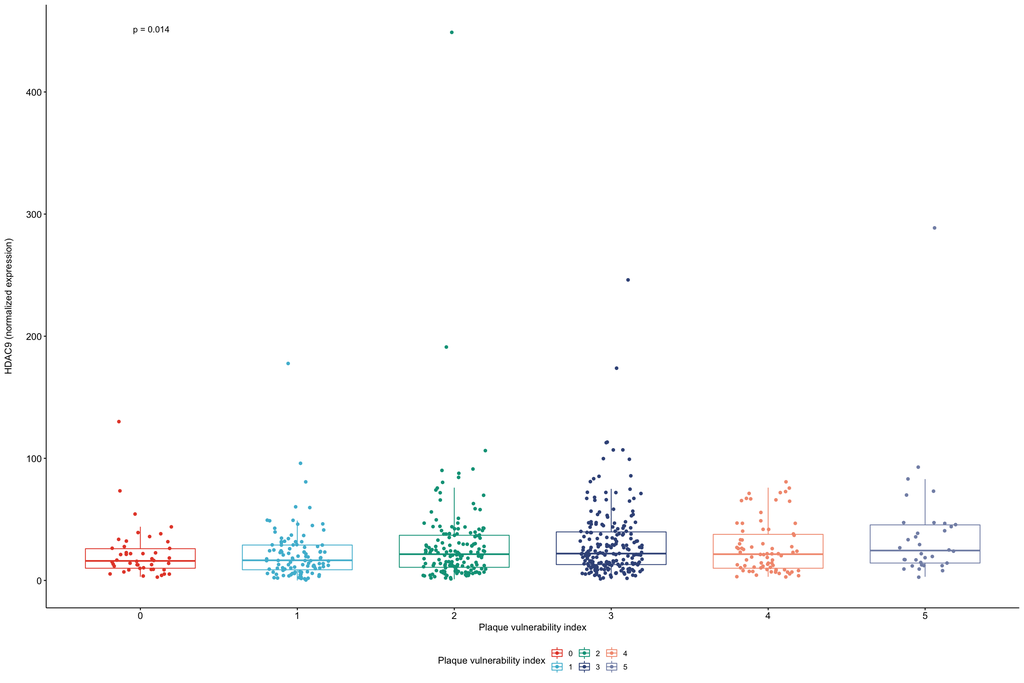

```r
p1 <- ggpubr::ggboxplot(AERNASE.clin.hdac9,
                  x = "Plaque_Vulnerability_Index",
                  y = "HDAC9",
                  xlab = "Plaque vulnerability index",
                  ylab = "HDAC9 (normalized expression)\n",
                  color = "Plaque_Vulnerability_Index",
                  palette = "npg",
                  add = "jitter") +
  stat_compare_means(label = "p.format",  method = "kruskal.test")
ggpar(p1, legend = "bottom", legend.title = "Plaque vulnerability index")
```

```r
ggsave(filename = paste0(PLOT_loc, "/", Today, ".",TRAIT_OF_INTEREST,".plaque.exp2_pgmL.PlaqueVulnerabilityIndex.pdf"), plot = last_plot())
compare_means(HDAC9 ~ Plaque_Vulnerability_Index, group.by = "Gender", data = AERNASE.clin.hdac9, method = "kruskal.test")
```

| Gender | .y. | p | p.adj | p.format | p.signif | method |
| --- | --- | --- | --- | --- | --- | --- |
| male | HDAC9 | 0.07804742 | 0.16 | 0.078 | ns | Kruskal-Wallis |
| female | HDAC9 | 0.17401240 | 0.17 | 0.174 | ns | Kruskal-Wallis |

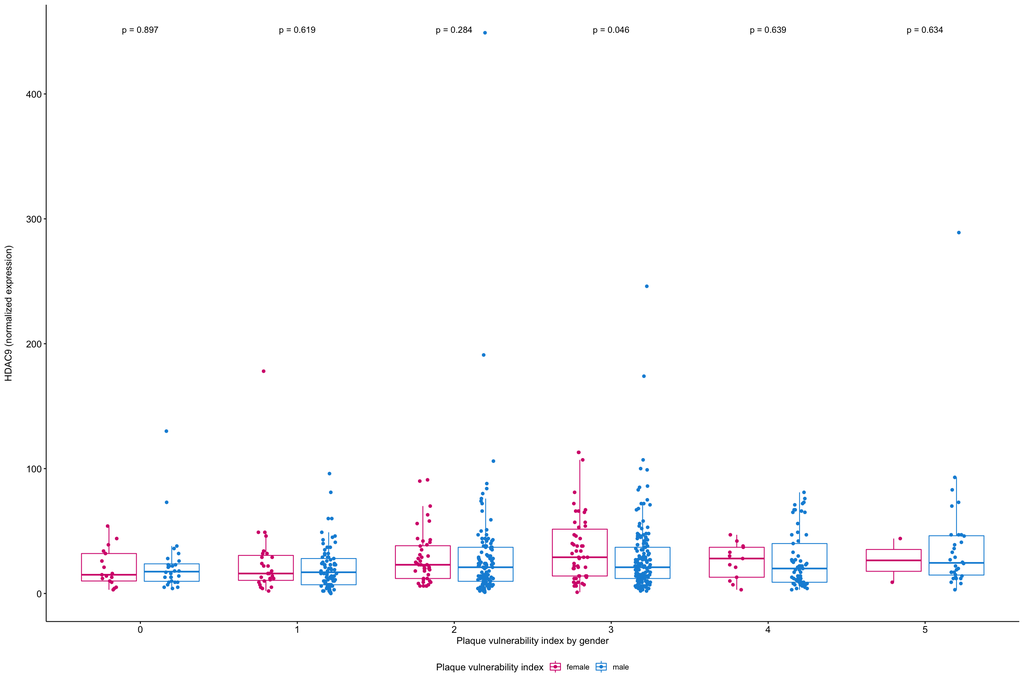

```r
p2 <- ggpubr::ggboxplot(AERNASE.clin.hdac9,
                  x = "Plaque_Vulnerability_Index",
                  y = "HDAC9",
                  xlab = "Plaque vulnerability index by gender",
                  ylab = "HDAC9 (normalized expression)\n",
                  color = "Gender",
                  palette = c("#D5267B", "#1290D9"),
                  add = "jitter") +
  stat_compare_means(aes(group = Gender), label = "p.format",  method = "kruskal.test")
ggpar(p2, legend = "bottom", legend.title = "Plaque vulnerability index")
```

```r
ggsave(filename = paste0(PLOT_loc, "/", Today, ".",TRAIT_OF_INTEREST,".plaque.exp2_pgmL.PlaqueVulnerabilityIndex.byGender.pdf"), plot = last_plot())
compare_means(HDAC9 ~ Plaque_Vulnerability_Index, data = AERNASE.clin.hdac9, method = "kruskal.test")
```

| .y. | p | p.adj | p.format | p.signif | method |
| --- | --- | --- | --- | --- | --- |
| HDAC9 | 0.01363071 | 0.014 | 0.014 | * | Kruskal-Wallis |

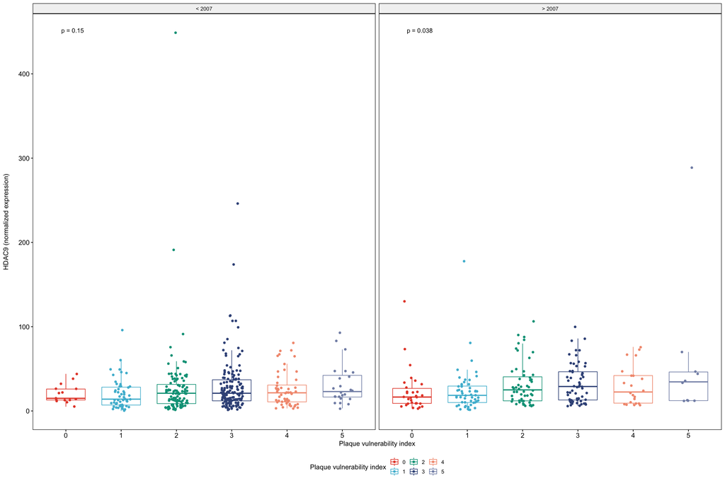

```r
p5 <- ggpubr::ggboxplot(AERNASE.clin.hdac9,
                  x = "Plaque_Vulnerability_Index",
                  y = "HDAC9",
                  xlab = "Plaque vulnerability index",
                  ylab = "HDAC9 (normalized expression)\n",
                  color = "Plaque_Vulnerability_Index",
                  palette = "npg",
                  facet.by = "ORyearGroup",
                  add = "jitter") +
  stat_compare_means(label = "p.format",  method = "kruskal.test")
ggpar(p5, legend = "bottom", legend.title = "Plaque vulnerability index")
```

```r
ggsave(filename = paste0(PLOT_loc, "/", Today, ".",TRAIT_OF_INTEREST,".plaque.exp2_pgmL.PlaqueVulnerabilityIndex_Facet_byYear.pdf"), plot = last_plot())
compare_means(HDAC9 ~ Plaque_Vulnerability_Index, group.by = "Gender", data = AERNASE.clin.hdac9, method = "kruskal.test")
```

| Gender | .y. | p | p.adj | p.format | p.signif | method |
| --- | --- | --- | --- | --- | --- | --- |
| male | HDAC9 | 0.07804742 | 0.16 | 0.078 | ns | Kruskal-Wallis |
| female | HDAC9 | 0.17401240 | 0.17 | 0.174 | ns | Kruskal-Wallis |

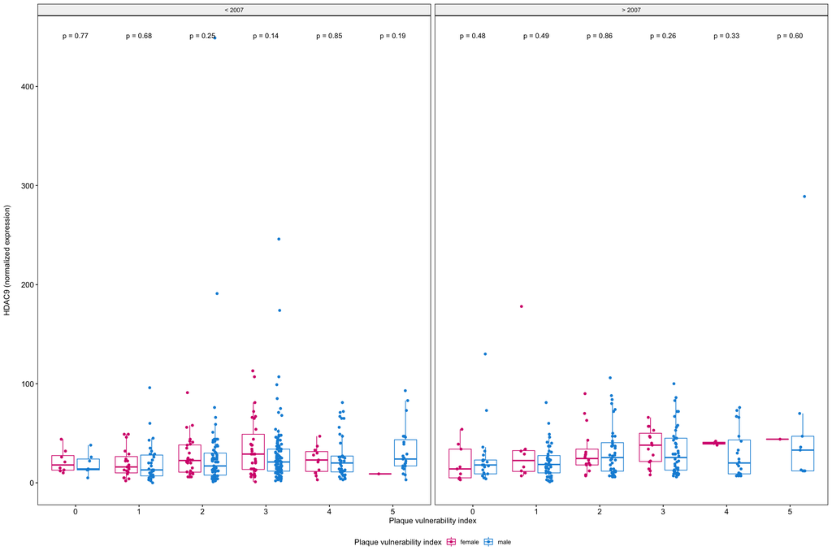

```r
p6 <- ggpubr::ggboxplot(AERNASE.clin.hdac9,
                  x = "Plaque_Vulnerability_Index",
                  y = "HDAC9",
                  xlab = "Plaque vulnerability index",
                  ylab = "HDAC9 (normalized expression)\n",
                  color = "Gender",
                  palette = c("#D5267B", "#1290D9"),
                  facet.by = "ORyearGroup",
                  add = "jitter") +
  stat_compare_means(aes(group = Gender), label = "p.format",  method = "kruskal.test")
ggpar(p6, legend = "bottom", legend.title = "Plaque vulnerability index")
```

```r
ggsave(filename = paste0(PLOT_loc, "/", Today, ".",TRAIT_OF_INTEREST,".plaque.exp2_pgmL.PlaqueVulnerabilityIndex_Facet_byYear.byGender.pdf"), plot = last_plot())
```

### Model 1

In this model we correct for *Age*, *Gender*, and *year of surgery*.

Analysis of the plaque vulnerability indez as a function of plaque HDAC9 levels.

```r
TRAITS.TARGET.RANK.extra = c("HDAC9")

GLM.results <- data.frame(matrix(NA, ncol = 16, nrow = 0))
for (protein in 1:length(TRAITS.TARGET.RANK.extra)) {
  PROTEIN = TRAITS.TARGET.RANK.extra[protein]
  cat(paste0("\nAnalysis of ",PROTEIN,".\n"))
  TRAIT = "Plaque_Vulnerability_Index"
    cat(paste0("\n- processing ",TRAIT,"\n\n"))
    currentDF <- as.data.frame(AERNASE.clin.hdac9 %>%
      dplyr::select(., PROTEIN, TRAIT, COVARIATES_M1) %>%
      filter(complete.cases(.))) %>%
      filter_if(~is.numeric(.), all_vars(!is.infinite(.))) %>%
      droplevels(.)

    # fix numeric OR year
    # currentDF$ORdate_year <- as.numeric(currentDF$ORdate_year)

    # for debug
    # print(DT::datatable(currentDF))
    # print(nrow(currentDF))
    # print(str(currentDF))
    # print(class(currentDF[,TRAIT]))
    # table(currentDF$ORdate_year)
    ### univariate
     # + Hypertension.composite + DiabetesStatus + SmokerCurrent +
     #            Med.Statin.LLD + Med.all.antiplatelet + GFR_MDRD + BMI +
     #            CAD_history + Stroke_history + Peripheral.interv + stenose
    # fit <- polr(currentDF[,TRAIT] ~ currentDF[,PROTEIN] + Age + Gender + ORdate_year,
    #           data  =  currentDF,
    #           Hess = TRUE)
    fit <- polr(currentDF[,TRAIT] ~ currentDF[,PROTEIN] + Age + Gender + ORdate_epoch,
              data  =  currentDF,
              Hess = TRUE)
    print(summary(fit))

    ## store table
    (ctable <- coef(summary(fit)))

    ## calculate and store p values
    p <- pnorm(abs(ctable[, "t value"]), lower.tail = FALSE) * 2

    ## combined table
    print((ctable <- cbind(ctable, "p value" = p)))
  }
```

```
Analysis of HDAC9.

- processing Plaque_Vulnerability_Index
```

```
Call:
polr(formula = currentDF[, TRAIT] ~ currentDF[, PROTEIN] + Age +
    Gender + ORdate_epoch, data = currentDF, Hess = TRUE)

Coefficients:
                          Value Std. Error t value
currentDF[, PROTEIN]  0.0069184  0.0026273   2.633
Age                   0.0124750  0.0007876  15.840
Gendermale            0.5460677  0.0029432 185.538
ORdate_epoch         -0.0004384        NaN     NaN

Intercepts:
    Value      Std. Error t value
0|1    -7.1513     0.0008 -8774.8479
1|2    -5.6841     0.0194  -292.8094
2|3    -4.4752     0.1029   -43.4887
3|4    -2.8315     0.1363   -20.7744
4|5    -1.5179     0.1398   -10.8560

Residual Deviance: 1961.92
AIC: 1979.92
```

```
                            Value   Std. Error      t value      p value
currentDF[, PROTEIN]  0.006918357 0.0026272954     2.633262 8.456906e-03
Age                   0.012475038 0.0007875536    15.840240 1.641939e-56
Gendermale            0.546067650 0.0029431603   185.537858 0.000000e+00
ORdate_epoch         -0.000438398          NaN          NaN          NaN
0|1                  -7.151291599 0.0008149761 -8774.847867 0.000000e+00
1|2                  -5.684099684 0.0194122864  -292.809387 0.000000e+00
2|3                  -4.475156538 0.1029038329   -43.488725 0.000000e+00
3|4                  -2.831470035 0.1362958897   -20.774435 7.372715e-96
4|5                  -1.517922118 0.1398234792   -10.855989 1.867744e-27
```

### Model 2

In this model we correct for *Age*, *Gender*, *Hypertension status*, *Diabetes status*, *current smoker status*, *lipid-lowering drugs (LLDs)*, *antiplatelet medication*, *eGFR (MDRD)*, *BMI*, *MedHx_CVD* (combination of *CAD history*, *stroke history*, and *peripheral interventions*), and *stenosis.*.

```r
for (protein in 1:length(TRAITS.TARGET.RANK.extra)) {
  PROTEIN = TRAITS.TARGET.RANK.extra[protein]
  cat(paste0("\nAnalysis of ",PROTEIN,".\n"))
  TRAIT = "Plaque_Vulnerability_Index"
    cat(paste0("\n- processing ",TRAIT,"\n\n"))
    currentDF <- as.data.frame(AERNASE.clin.hdac9 %>%
      dplyr::select(., PROTEIN, TRAIT, COVARIATES_M2) %>%
      filter(complete.cases(.))) %>%
      filter_if(~is.numeric(.), all_vars(!is.infinite(.))) %>%
      droplevels(.)

    # fix numeric OR year
    # currentDF$ORdate_year <- as.numeric(currentDF$ORdate_year)

    # for debug
    # print(DT::datatable(currentDF))
    # print(nrow(currentDF))
    # print(str(currentDF))
    # print(class(currentDF[,TRAIT]))
    ### univariate

    # fit <- polr(as.factor(currentDF[,TRAIT]) ~ currentDF[,PROTEIN] + Age + Gender + ORdate_year + Hypertension.composite + DiabetesStatus + SmokerStatus + Med.Statin.LLD + Med.all.antiplatelet + GFR_MDRD + BMI + MedHx_CVD + stenose,
    #           data  =  currentDF,
    #           Hess = TRUE)

    fit <- polr(as.factor(currentDF[,TRAIT]) ~ currentDF[,PROTEIN] + Age + Gender + ORdate_epoch + Hypertension.composite + DiabetesStatus + SmokerStatus + Med.Statin.LLD + Med.all.antiplatelet + GFR_MDRD + BMI + MedHx_CVD + stenose,
              data  =  currentDF,
              Hess = TRUE)

    print(summary(fit))

    ## store table
    (ctable <- coef(summary(fit)))

    ## calculate and store p values
    p <- pnorm(abs(ctable[, "t value"]), lower.tail = FALSE) * 2

    ## combined table
    print((ctable <- cbind(ctable, "p value" = p)))
  }
```

```
Analysis of HDAC9.

- processing Plaque_Vulnerability_Index
```

```
Call:
polr(formula = as.factor(currentDF[, TRAIT]) ~ currentDF[, PROTEIN] +
    Age + Gender + ORdate_epoch + Hypertension.composite + DiabetesStatus +
    SmokerStatus + Med.Statin.LLD + Med.all.antiplatelet + GFR_MDRD +
    BMI + MedHx_CVD + stenose, data = currentDF, Hess = TRUE)

Coefficients:
                               Value Std. Error    t value
currentDF[, PROTEIN]        0.007791  2.857e-03  2.727e+00
Age                         0.012450  5.885e-03  2.116e+00
Gendermale                  0.538602  2.577e-03  2.090e+02
ORdate_epoch               -0.000541        NaN        NaN
Hypertension.compositeyes  -0.049872  8.558e-04 -5.828e+01
DiabetesStatusDiabetes     -0.105116  3.196e-04 -3.289e+02
SmokerStatusEx-smoker       0.058168  1.202e-03  4.839e+01
SmokerStatusNever smoked    0.289037  7.098e-04  4.072e+02
Med.Statin.LLDyes           0.062784  1.284e-03  4.891e+01
Med.all.antiplateletyes     0.090098  1.159e-03  7.774e+01
GFR_MDRD                    0.001444  3.393e-03  4.256e-01
BMI                        -0.043742  1.625e-02 -2.691e+00
MedHx_CVDNo                -0.221798  2.329e-03 -9.525e+01
stenose50-70%              -0.521282  2.560e-04 -2.036e+03
stenose70-90%              -0.901200  2.429e-03 -3.711e+02
stenose90-99%              -1.283931  2.446e-03 -5.250e+02
stenose100% (Occlusion)    -1.719726  6.903e-05 -2.491e+04
stenose50-99%             -28.618763  3.029e-11 -9.449e+11

Intercepts:
    Value         Std. Error    t value
0|1 -1.061660e+01  5.000000e-04 -2.090716e+04
1|2 -9.111700e+00  2.240000e-02 -4.075256e+02
2|3 -7.888900e+00  1.129000e-01 -6.986070e+01
3|4 -6.218700e+00  1.488000e-01 -4.180540e+01
4|5 -4.890200e+00  1.529000e-01 -3.197420e+01

Residual Deviance: 1670.926
AIC: 1716.926
```

```
                                  Value   Std. Error       t value       p value
currentDF[, PROTEIN]       7.791379e-03 2.857069e-03  2.727053e+00  6.390278e-03
Age                        1.244976e-02 5.884999e-03  2.115507e+00  3.438674e-02
Gendermale                 5.386019e-01 2.576587e-03  2.090369e+02  0.000000e+00
ORdate_epoch              -5.409604e-04          NaN           NaN           NaN
Hypertension.compositeyes -4.987198e-02 8.557950e-04 -5.827562e+01  0.000000e+00
DiabetesStatusDiabetes    -1.051157e-01 3.195562e-04 -3.289428e+02  0.000000e+00
SmokerStatusEx-smoker      5.816763e-02 1.202102e-03  4.838828e+01  0.000000e+00
SmokerStatusNever smoked   2.890373e-01 7.098100e-04  4.072037e+02  0.000000e+00
Med.Statin.LLDyes          6.278367e-02 1.283646e-03  4.891043e+01  0.000000e+00
Med.all.antiplateletyes    9.009768e-02 1.158925e-03  7.774248e+01  0.000000e+00
GFR_MDRD                   1.444008e-03 3.392560e-03  4.256396e-01  6.703705e-01
BMI                       -4.374247e-02 1.625429e-02 -2.691134e+00  7.120958e-03
MedHx_CVDNo               -2.217979e-01 2.328509e-03 -9.525319e+01  0.000000e+00
stenose50-70%             -5.212822e-01 2.560112e-04 -2.036169e+03  0.000000e+00
stenose70-90%             -9.012001e-01 2.428538e-03 -3.710875e+02  0.000000e+00
stenose90-99%             -1.283931e+00 2.445602e-03 -5.249956e+02  0.000000e+00
stenose100% (Occlusion)   -1.719726e+00 6.903322e-05 -2.491158e+04  0.000000e+00
stenose50-99%             -2.861876e+01 3.028878e-11 -9.448636e+11  0.000000e+00
0|1                       -1.061656e+01 5.077954e-04 -2.090716e+04  0.000000e+00
1|2                       -9.111703e+00 2.235861e-02 -4.075256e+02  0.000000e+00
2|3                       -7.888915e+00 1.129235e-01 -6.986070e+01  0.000000e+00
3|4                       -6.218676e+00 1.487528e-01 -4.180543e+01  0.000000e+00
4|5                       -4.890208e+00 1.529422e-01 -3.197422e+01 2.489352e-224
```

# Session information

```
Version:      v1.0.0
Last update:  2021-03-19
Written by:   Sander W. van der Laan (s.w.vanderlaan-2[at]umcutrecht.nl).
Description:  Script to analyse HDAC9 from the Ather-Express Biobank Study.
Minimum requirements: R version 3.5.2 (2018-12-20) -- 'Eggshell Igloo', macOS Mojave (10.14.2).

**MoSCoW To-Do List**
The things we Must, Should, Could, and Would have given the time we have.
_M_

_S_

_C_

_W_

**Changes log**
* v1.0.0 Inital version.
```

# Saving environment

```r
save.image(paste0(PROJECT_loc, "/",Today,".",PROJECTNAME,".bulkRNAseq.additional_figures.RData"))
```

| <sup>© 1979-2022 Sander W. van der Laan \| s.w.vanderlaan[at]gmail.com \| swvanderlaan.github.io.</sup> |
| --- |